# Predictive Modelling Cars

By studying the classes of all 9 attributes it can be said that “Engineer”, “MBA” and “License” attributes needs to be converted into a factor.

```r
str(Cars_New)
```

```
## 'data.frame':    418 obs. of  9 variables:
##  $ Age      : int  28 24 27 25 25 21 23 23 24 28 ...
##  $ Gender   : chr  "Male" "Male" "Female" "Male" ...
##  $ Engineer : int  1 1 1 0 0 0 1 0 1 1 ...
##  $ MBA      : int  0 0 0 0 0 0 1 0 0 0 ...
##  $ Work.Exp : int  5 6 9 1 3 3 3 0 4 6 ...
##  $ Salary   : num  14.4 10.6 15.5 7.6 9.6 9.5 11.7 6.5 8.5 13.7 ...
##  $ Distance : num  5.1 6.1 6.1 6.3 6.7 7.1 7.2 7.3 7.5 7.5 ...
##  $ license  : int  0 0 0 0 0 0 0 0 0 1 ...
##  $ Transport: chr  "2Wheeler" "2Wheeler" "2Wheeler" "2Wheeler" ...
```

```r
Cars_New$Engineer = as.factor(Cars_New$Engineer)
Cars_New$MBA = as.factor(Cars_New$MBA)
Cars_New$license = as.factor(Cars_New$license)
summary(Cars_New)
```

```
##       Age           Gender          Engineer MBA        Work.Exp
##  Min.   :18.00   Length:418         0:105    0:309   Min.   : 0.000
##  1st Qu.:25.00   Class :character   1:313    1:109   1st Qu.: 3.000
##  Median :27.00   Mode  :character                    Median : 5.000
##  Mean   :27.33                                       Mean   : 5.873
##  3rd Qu.:29.00                                       3rd Qu.: 8.000
##  Max.   :43.00                                       Max.   :24.000
##      Salary          Distance     license  Transport
##  Min.   : 6.500   Min.   : 3.20   0:333   Length:418
##  1st Qu.: 9.625   1st Qu.: 8.60   1: 85   Class :character
##  Median :13.000   Median :10.90           Mode  :character
##  Mean   :15.418   Mean   :11.29
##  3rd Qu.:14.900   3rd Qu.:13.57
##  Max.   :57.000   Max.   :23.40
```

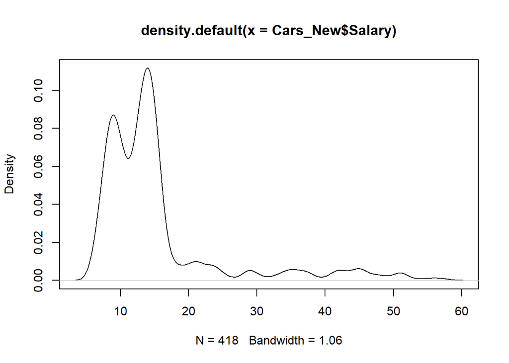

```r
plot(density(Cars_New$Salary))
```

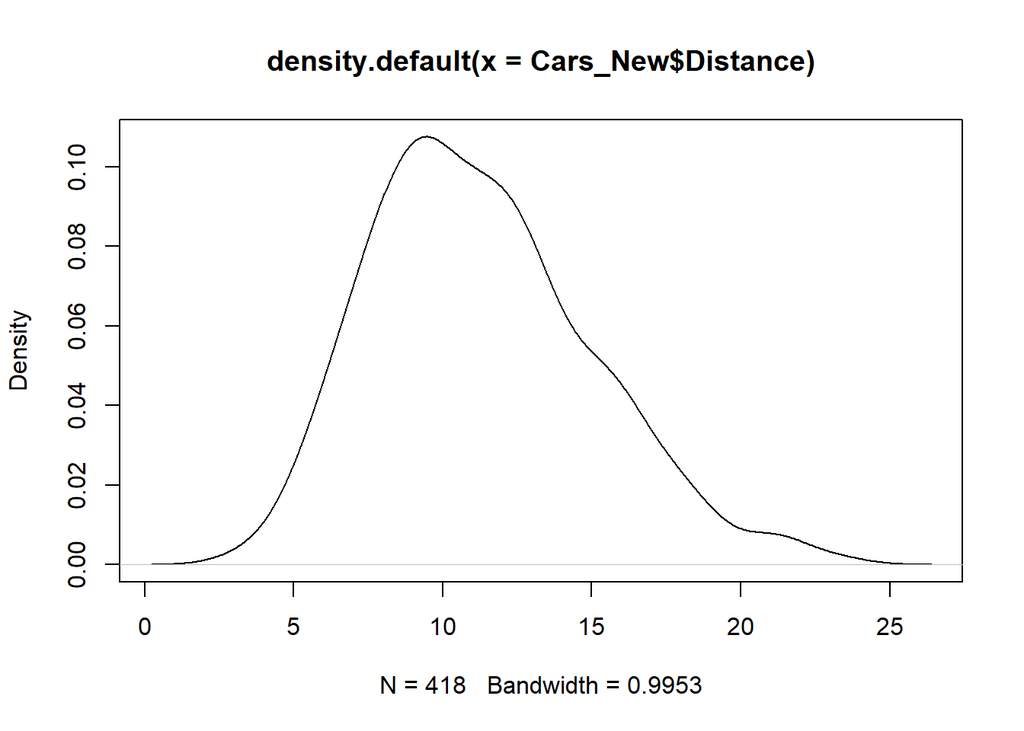

```r
plot(density(Cars_New$Distance))
```

```r
range(Cars_New$Work.Exp)
```

```
## [1]  0 24
```

MULTI COLINEARITY CHECK

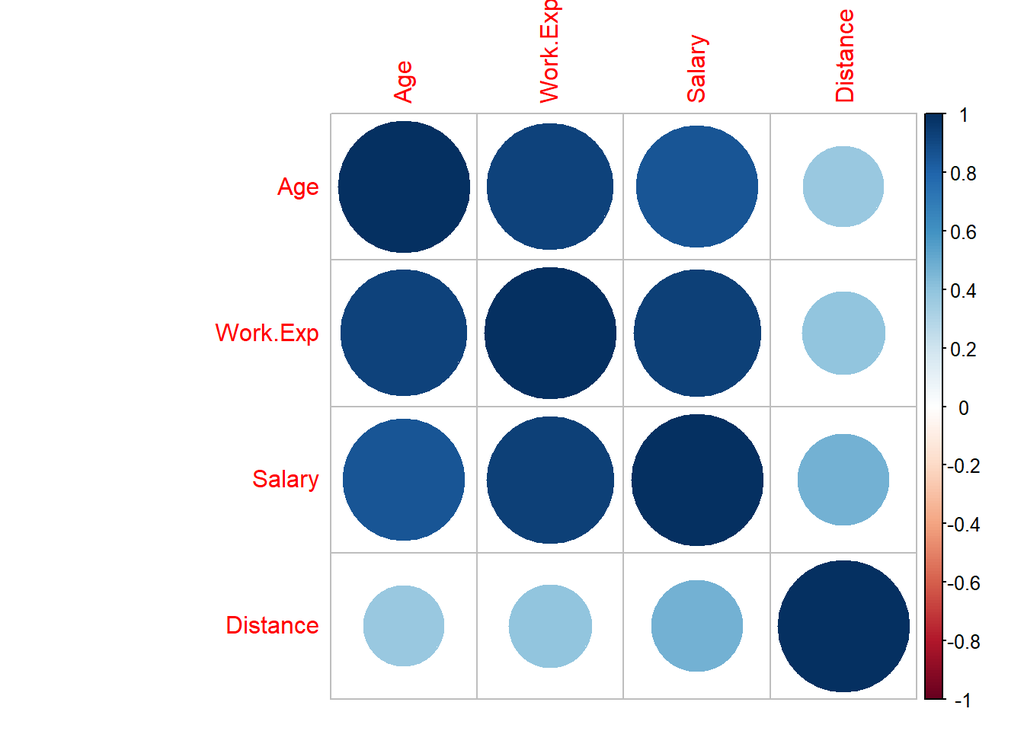

```r
corrplot(cor(Cars_New[,c(1,5,6,7)]))
```

```r
cor(Cars_New$Age,Cars_New$Salary)
```

```
## [1] 0.8577839
```

```r
cor(Cars_New$Work.Exp,Cars_New$Salary)
```

```
## [1] 0.9318099
```

```r
cor(Cars_New$Age,Cars_New$Work.Exp)
```

```
## [1] 0.9244297
```

```r
cor(Cars_New$Distance,Cars_New$Salary)
```

```
## [1] 0.478355
```

```r
cor(Cars_New$Age,Cars_New$Distance)
```

```
## [1] 0.3751402
```

We can see from the above correlation plot that Salary is very well correlated with both the Age and the Work experience to each other.

cor(Age,Salary) = 86% cor(Work.Exp,Salary) = 93.2% cor(Age,Work.Exp) = 93% cor(Distance,Salary) = 48% cor(Age,Distance) = 38%

## TRANSPORT :

As we can see that the original dataset predicted variable mode of transport contains of 3 levels of catergorical variables. i.e: 2 Wheelers, Public Transport and Cars

Therfore, another coloumns have been created using “dummy variable” statistical tool to create minimise the number of levels in the predicted variable coloumn. Therefore, a new coloumn called “Transport.cars” have been created with a binary value 1 to represent all the employee who would take the car and “0” for other mode of transport.

```r
levels(Cars_New$Transport)
```

```r
Cars_New_Transform = Cars_New
# Dummy Variable for Transport
Transport.cars=c("Car")
Cars_New_Transform$Transport.cars = ifelse(Cars_New_Transform$Transport %in% Transport.cars,1,0)

# Dummy Variable for Gender
Male=c("Male")
Female=c("Female")

Cars_New_Transform$Male = ifelse(Cars_New_Transform$Gender %in% Male,1,0)
Cars_New_Transform$Female = ifelse(Cars_New_Transform$Gender %in% Female,1,0)


attach(Cars_New_Transform)
View(Cars_New_Transform)
class(Cars_New_Transform)
```

```
## [1] "data.frame"
```

```r
Cars_New_Transform$Transport.cars=as.factor(Cars_New_Transform$Transport.cars)
Cars_New_Transform$Male=as.factor(Cars_New_Transform$Male)
Cars_New_Transform$Female=as.factor(Cars_New_Transform$Female)
str(Cars_New_Transform)
```

```
## 'data.frame':    418 obs. of  12 variables:
##  $ Age           : int  28 24 27 25 25 21 23 23 24 28 ...
##  $ Gender        : chr  "Male" "Male" "Female" "Male" ...
##  $ Engineer      : Factor w/ 2 levels "0","1": 2 2 2 1 1 1 2 1 2 2 ...
##  $ MBA           : Factor w/ 2 levels "0","1": 1 1 1 1 1 1 2 1 1 1 ...
##  $ Work.Exp      : int  5 6 9 1 3 3 3 0 4 6 ...
##  $ Salary        : num  14.4 10.6 15.5 7.6 9.6 9.5 11.7 6.5 8.5 13.7 ...
##  $ Distance      : num  5.1 6.1 6.1 6.3 6.7 7.1 7.2 7.3 7.5 7.5 ...
##  $ license       : Factor w/ 2 levels "0","1": 1 1 1 1 1 1 1 1 1 2 ...
##  $ Transport     : chr  "2Wheeler" "2Wheeler" "2Wheeler" "2Wheeler" ...
##  $ Transport.cars: Factor w/ 2 levels "0","1": 1 1 1 1 1 1 1 1 1 1 ...
##  $ Male          : Factor w/ 2 levels "0","1": 2 2 1 2 1 2 2 2 2 2 ...
##  $ Female        : Factor w/ 2 levels "0","1": 1 1 2 1 2 1 1 1 1 1 ...
```

```r
head(Cars_New_Transform,150)
```

```
##     Age Gender Engineer MBA Work.Exp Salary Distance license        Transport
## 1    28   Male        1   0        5   14.4      5.1       0         2Wheeler
## 2    24   Male        1   0        6   10.6      6.1       0         2Wheeler
## 3    27 Female        1   0        9   15.5      6.1       0         2Wheeler
## 4    25   Male        0   0        1    7.6      6.3       0         2Wheeler
## 5    25 Female        0   0        3    9.6      6.7       0         2Wheeler
## 6    21   Male        0   0        3    9.5      7.1       0         2Wheeler
## 7    23   Male        1   1        3   11.7      7.2       0         2Wheeler
## 8    23   Male        0   0        0    6.5      7.3       0         2Wheeler
## 9    24   Male        1   0        4    8.5      7.5       0         2Wheeler
## 10   28   Male        1   0        6   13.7      7.5       1         2Wheeler
## 11   26   Male        0   0        4   12.6      7.5       0         2Wheeler
## 12   21   Male        0   1        3   10.6      7.7       0         2Wheeler
## 13   22 Female        1   0        2    8.5      8.1       0         2Wheeler
## 14   24   Male        1   0        6   12.7      8.7       0         2Wheeler
```

[output cut: 287 more lines]

## EDUCATION BACKGROUND:

```r
Cars_New_Transform$Education  = mutate(Cars_New_Transform,Engineer=
                                         ifelse(Cars_New_Transform$Engineer == 1,"1","0"))

View(Cars_New_Transform)
```

## STATISTICAL CONFIRMATIONS ON ASSUMPTIONS:

## ASSUMPTION - 1:

Before we proced with any analysis, Normality hypothesis test must be done ensure the Normal Distribution of the variables in the given cars dataset.

The hypothesis for the Normality Test is given below. H0 = The dataset follows a Normal Distribution Against the alternative Hypothesis as, Ha = The dataset does not follow the Normal Distribution properties.

The “Shapiro-Wilk Normality Test” is conducted to investigate the Assumption -1.

There are 4 numeric variables in the dataset. The outcome of the Shapiro-Wilks test on each variable is tabulated below.

| VARIABLE | p-Value |
| --- | --- |
| Age | 8.594e-14 |
| Salary | 2.2e-16 |
| Work.Exp | 2.2e-16 |
| Distance | 5.843e-06 |

```r
#attach(Cars_New_Transform)
shapiro.test (Age) #Shapiro-Wilk normality test
```

```
##
##  Shapiro-Wilk normality test
##
## data:  Age
## W = 0.92321, p-value = 8.594e-14
```

```r
shapiro.test (Salary) #Shapiro-Wilk normality test
```

```
##
##  Shapiro-Wilk normality test
##
## data:  Salary
## W = 0.69305, p-value < 2.2e-16
```

```r
shapiro.test(Work.Exp)
```

```
##
##  Shapiro-Wilk normality test
##
## data:  Work.Exp
## W = 0.8544, p-value < 2.2e-16
```

```r
shapiro.test(Distance)
```

```
##
##  Shapiro-Wilk normality test
##
## data:  Distance
## W = 0.97805, p-value = 5.843e-06
```

```r
View(Cars_New_Transform)
```

## ASSUMPTION - 1:

In addition to the above test one more test needs to be conducted to confirm the homogeneity of variance assumption by doing a “Levene Test”.

The Hypothesis testing is done on each variable such as “Age”,“Work.Exp”,“Distance” and “Salary”. Variance on each dataset is checked against the transport classification.

Ho : Variance are equal. Ha : At least one variance is different

```r
leveneTest(Age~Transport.cars,Cars_New_Transform)   # Levene's Test for Homogeneity of Variance in Age
```

```
## Levene's Test for Homogeneity of Variance (center = median)
##        Df F value Pr(>F)
## group   1  1.2186 0.2703
##       416
```

```r
round(leveneTest(Age~Transport.cars,Cars_New_Transform),3)  # Rounding up the Levene's Test value to 3 decimal places.
```

```
## Levene's Test for Homogeneity of Variance (center = median)
##        Df F value Pr(>F)
## group   1   1.219   0.27
##       416
```

```r
leveneTest(Work.Exp~Transport.cars,Cars_New_Transform)   # Levene's Test for Homogeneity of Variance in Age
```

```
## Levene's Test for Homogeneity of Variance (center = median)
##        Df F value Pr(>F)
## group   1  2.2326 0.1359
##       416
```

```r
round(leveneTest(Work.Exp~Transport.cars,Cars_New_Transform),3)  # Rounding up the Levene's Test value to 3 decimal places.
```

```
## Levene's Test for Homogeneity of Variance (center = median)
##        Df F value Pr(>F)
## group   1   2.233  0.136
##       416
```

```r
leveneTest(Distance~Transport.cars,Cars_New_Transform)   # Levene's Test for Homogeneity of Variance in Age
```

```
## Levene's Test for Homogeneity of Variance (center = median)
##        Df F value Pr(>F)
## group   1  1.6957 0.1936
##       416
```

```r
round(leveneTest(Distance~Transport.cars,Cars_New_Transform),3)  # Rounding up the Levene's Test value to 3 decimal places.
```

```
## Levene's Test for Homogeneity of Variance (center = median)
##        Df F value Pr(>F)
## group   1   1.696  0.194
##       416
```

```r
leveneTest(Salary~Transport.cars,Cars_New_Transform)   # Levene's Test for Homogeneity of Variance in Age
```

```
## Levene's Test for Homogeneity of Variance (center = median)
##        Df F value    Pr(>F)
## group   1  24.611 1.024e-06 ***
##       416
## ---
## Signif. codes:  0 '***' 0.001 '**' 0.01 '*' 0.05 '.' 0.1 ' ' 1
```

```r
round(leveneTest(Salary~Transport.cars,Cars_New_Transform),3)  # Rounding up the Levene's Test value to 3 decimal places.
```

```
## Levene's Test for Homogeneity of Variance (center = median)
##        Df F value    Pr(>F)
## group   1  24.611 < 2.2e-16 ***
##       416
## ---
## Signif. codes:  0 '***' 0.001 '**' 0.01 '*' 0.05 '.' 0.1 ' ' 1
```

NOTE: Except “Salary” all other variables have shown to obey the Homogenity of variation based on the “Transport Classification”. “Levene Test” confirms that.

## UNIVARIATE ANALYSIS:

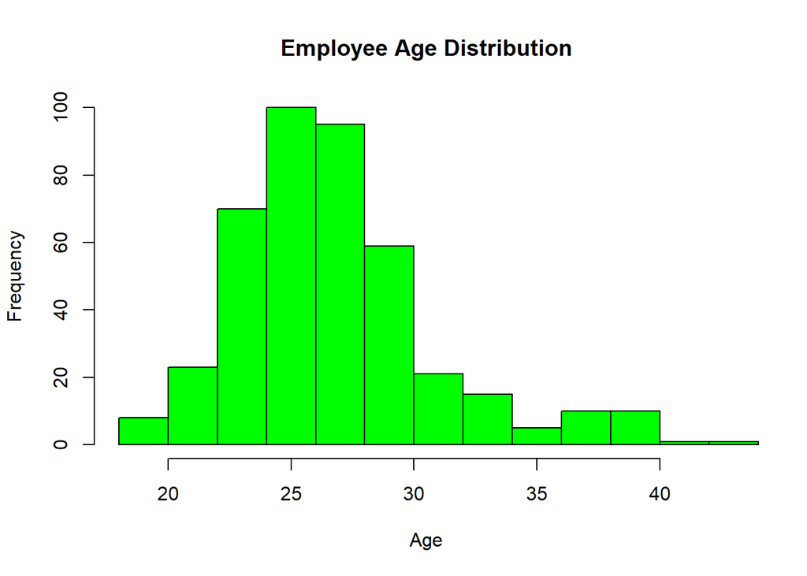

```r
hist(Cars_New$Age,col="Green",xlim=c(18,43),
     main="Employee Age Distribution",xlab="Age",breaks = 10)
```

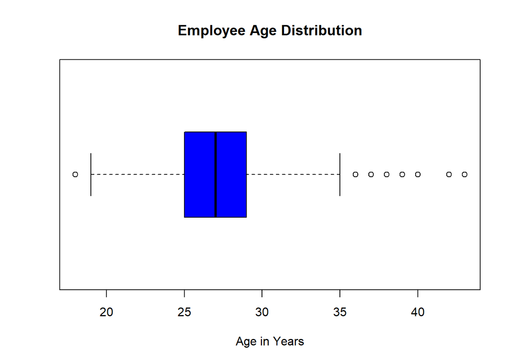

```r
boxplot(Cars_New$Age,
        horizontal = TRUE,col="blue",main = "Employee Age Distribution", xlab= "Age in Years")
```

As observed from the “Age” histogram, most number of outliers were observed at the upper side of the age spectrum.This is confirmed by the boxplot diagram. The calculated 26 outliers are listed out below: 38 38 40 36 40 37 39 40 38 36 39 38 40 39 38 42 40 37 43 40 38 37 37 39 36 36

In addition to that there were two repeated outliers were observed at lower end of the distribution spectrum.i.e: 18,18.

```r
attach(Cars_New)
# OUTLIER CALCULATION
mean(Age)
```

```
## [1] 27.33493
```

```r
median(Age)
```

```
## [1] 27
```

```r
Age_IQR = IQR(Age)
Age_IQR
```

```
## [1] 4
```

```r
#OUTLIERS - Q3
Q3_Age = quantile(Age,0.75)
Q3_Age = unname(Q3_Age)
Q3_Age
```

```
## [1] 29
```

```r
#OUTLIERs - Q1
Q1_Age = unname(quantile(Age,0.25))
Q1_Age
```

```
## [1] 25
```

```r
# IQR CALCULATION
Max_Age_IQR = Q3_Age+1.5*Age_IQR # Positive Outlier Calculation
Max_Age_IQR
```

```
## [1] 35
```

```r
Min_Age_IQR = Q1_Age-1.5*Age_IQR # Negative Outlier Calculation
Min_Age_IQR
```

```
## [1] 19
```

```r
# No Of OUTLIERS
sum(Age > Max_Age_IQR)
```

```
## [1] 26
```

```r
sum(Age < Min_Age_IQR)
```

```
## [1] 2
```

```r
# Print all Outliers
Age[Age > Max_Age_IQR]
```

```
##  [1] 38 38 40 36 40 37 39 40 38 36 39 38 40 39 38 42 40 37 43 40 38 37 37 39 36
## [26] 36
```

```r
Age[Age < Min_Age_IQR]
```

```
## [1] 18 18
```

WORK EXPERIENCE: The “Work.Exp” attribute have a mean of 5.873 and the median of 5 with a minimum of “No Experience” at all and maximum of 24 years. By theory and the grpahical representatio through an experience also indicates that work experience takes a Rightly Skewed distribution. Equal and tall bars were observed at between the value of 0 to 5. Also, I suspect there could be outlier at the right side of the spectrum.

```r
attach(Cars_New)
```

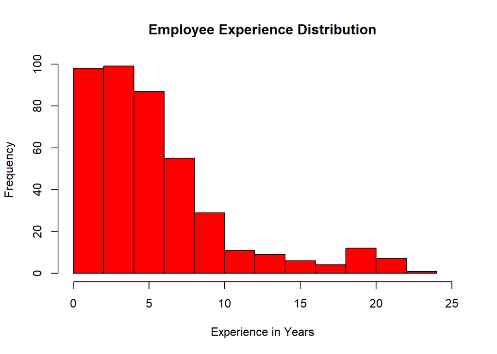

```r
hist(Work.Exp,col="Red",xlim=c(0,25),
     main="Employee Experience Distribution",xlab="Experience in Years" ,breaks = 10)
```

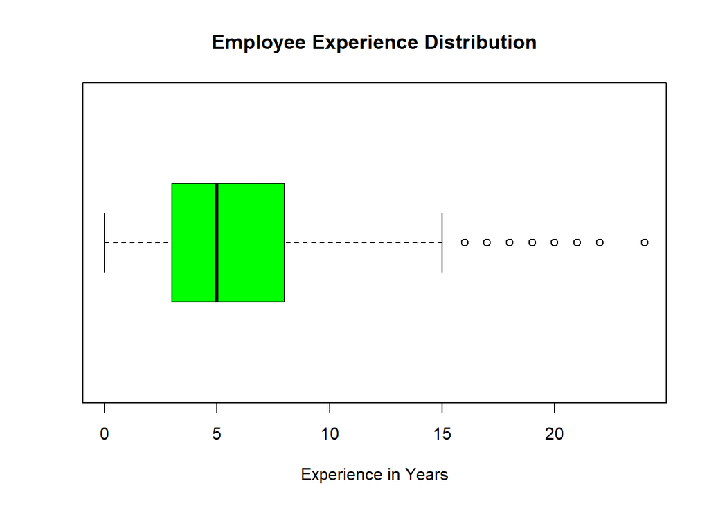

```r
boxplot(Work.Exp,
        horizontal = TRUE,col="Green",main = "Employee Experience Distribution", xlab= "Experience in Years")
```

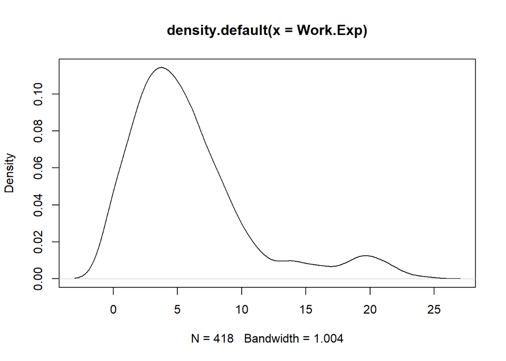

```r
plot(density(Work.Exp))
```

As suspected it can be seen from the outlier calculation that, there are no minimum outliers in the dataset. In contrast there 29 datapoint were identified as outliers located beyond the Max_IQR value for employee gained work experience attribute. The each observed outliers are listed below. 19 20 22 16 20 18 21 20 20 16 17 21 18 20 21 19 22 22 19 24 20 19 19 19 21 16 16 18 16.

```r
# OUTLIER CALCULATION
mean(Work.Exp)
```

```
## [1] 5.873206
```

```r
median(Work.Exp)
```

```
## [1] 5
```

```r
Work.Exp_IQR = IQR(Work.Exp)
Work.Exp_IQR
```

```
## [1] 5
```

```r
#OUTLIERS - Q3
Q3_Work.Exp = quantile(Work.Exp,0.75)
Q3_Work.Exp = unname(Q3_Work.Exp)
Q3_Work.Exp
```

```
## [1] 8
```

```r
#OUTLIERs - Q1
Q1_Work.Exp = unname(quantile(Work.Exp,0.25))
Q1_Work.Exp
```

```
## [1] 3
```

```r
# IQR CALCULATION
Max_Work.Exp_IQR = Q3_Work.Exp+1.5*Work.Exp_IQR # Positive Outlier Calculation
Max_Work.Exp_IQR
```

```
## [1] 15.5
```

```r
Min_Work.Exp_IQR = Q1_Work.Exp-1.5*Work.Exp_IQR # Negative Outlier Calculation
Min_Work.Exp_IQR
```

```
## [1] -4.5
```

```r
# No Of OUTLIERS
sum(Work.Exp > Max_Work.Exp_IQR)
```

```
## [1] 29
```

```r
sum(Work.Exp < Min_Work.Exp_IQR)
```

```
## [1] 0
```

```r
# Print all Outliers
Work.Exp[Work.Exp > Max_Work.Exp_IQR]
```

```
##  [1] 19 20 22 16 20 18 21 20 20 16 17 21 18 20 21 19 22 22 19 24 20 19 19 19 21
## [26] 16 16 18 16
```

```r
Work.Exp[Work.Exp < Min_Work.Exp_IQR]
```

```
## integer(0)
```

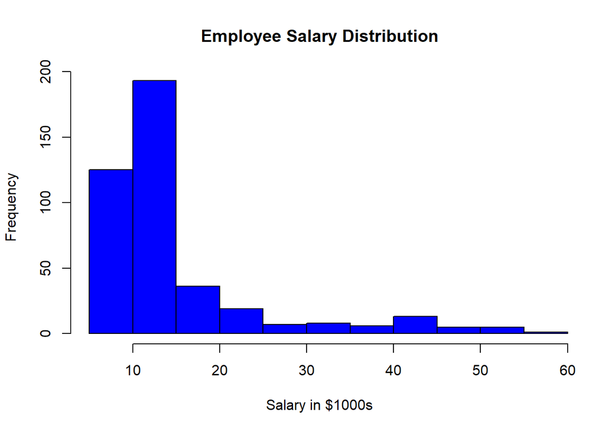

```r
hist(Cars_New$Salary,col="Blue",xlim=c(5,58),
     main="Employee Salary Distribution",xlab="Salary in $1000s",breaks=10)
```

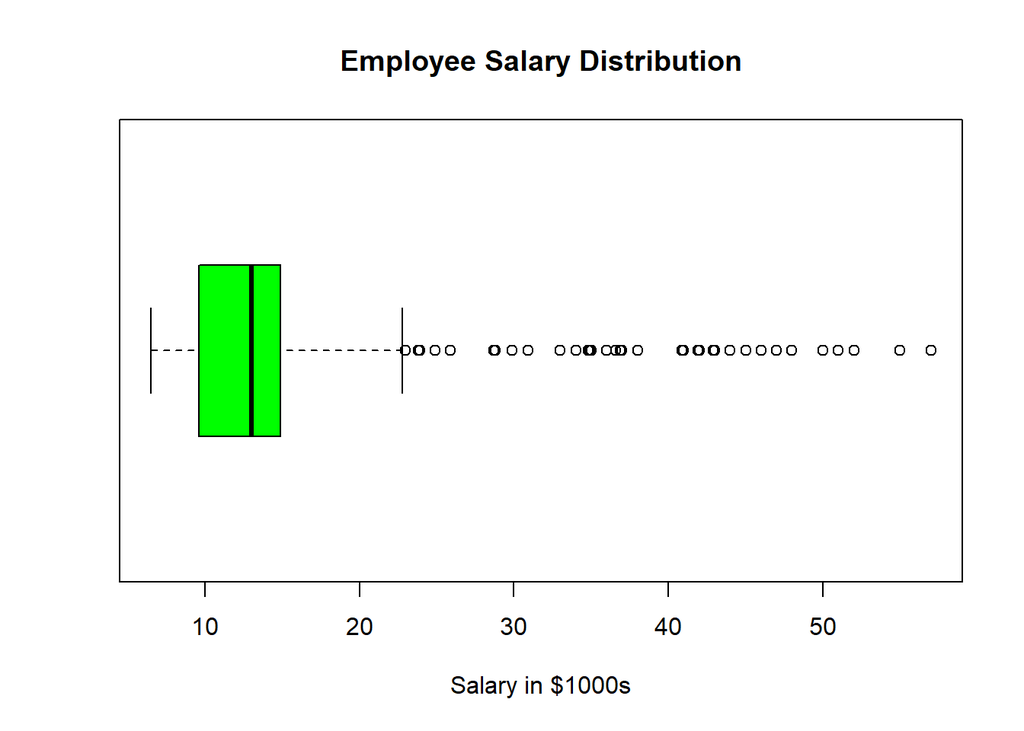

```r
boxplot(Salary,horizontal = TRUE,col="Green",main = "Employee Salary Distribution", xlab= "Salary in $1000s")
```

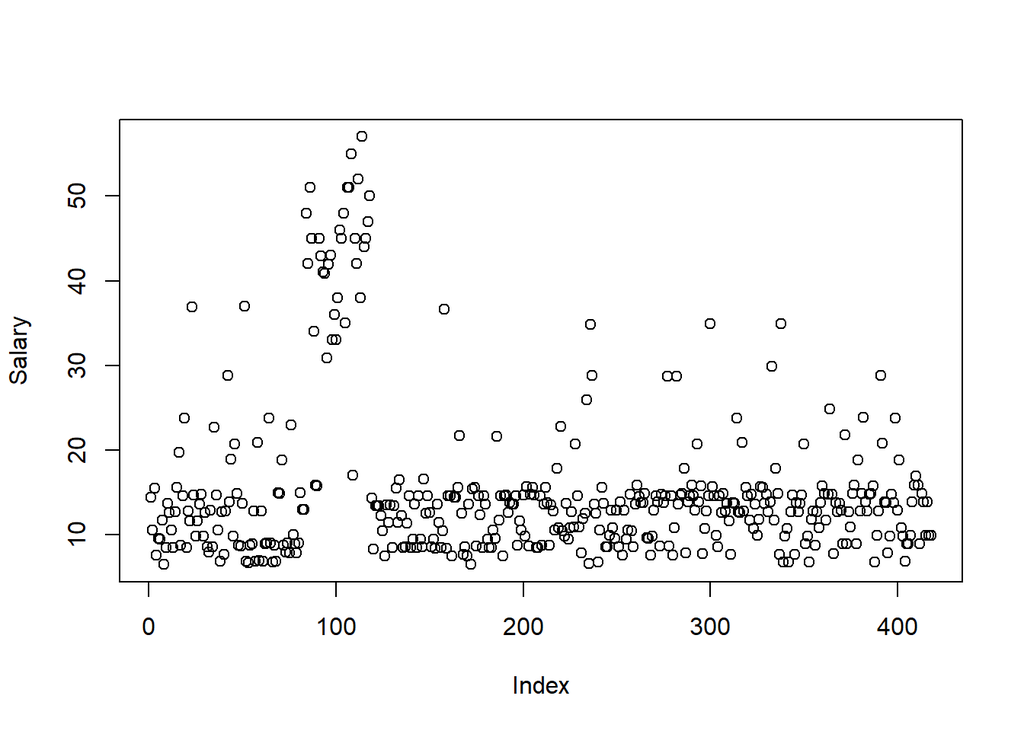

```r
plot(Salary)
```

52 outlier points were identified at the right side of the “Salary” variable distribution spectrum. The list of outliers are:

23.8 36.9 28.8 37.0 23.8 23.0 48.0 42.0 51.0 45.0 34.0 45.0 42.9 41.0 40.9 30.9 41.9 43.0 33.0 36.0 33.0 38.0 46.0 45.0 48.0 35.0 51.0 51.0 55.0 45.0 42.0 52.0 38.0 57.0 44.0 45.0 47.0 50.0 36.6 25.9 34.8 28.8 28.7 28.7 34.9 23.8 29.9 34.9 24.9 23.9 28.8 23.8.

```r
# OUTLIER CALCULATION
mean(Salary)
```

```
## [1] 15.41842
```

```r
median(Salary)
```

```
## [1] 13
```

```r
Salary_IQR = IQR(Salary)
Salary_IQR
```

```
## [1] 5.275
```

```r
#OUTLIERS - Q3
Q3_Salary = quantile(Salary,0.75)
Q3_Salary = unname(Q3_Salary)
Q3_Salary
```

```
## [1] 14.9
```

```r
#OUTLIERs - Q1
Q1_Salary = unname(quantile(Salary,0.25))
Q1_Salary
```

```
## [1] 9.625
```

```r
# IQR CALCULATION
Max_Salary_IQR = Q3_Salary+1.5*Salary_IQR # Positive Outlier Calculation
Max_Salary_IQR
```

```
## [1] 22.8125
```

```r
Min_Salary_IQR = Q1_Salary-1.5*Salary_IQR # Negative Outlier Calculation
Min_Salary_IQR
```

```
## [1] 1.7125
```

```r
# No Of OUTLIERS
sum(Salary > Max_Salary_IQR)
```

```
## [1] 52
```

```r
sum(Salary < Min_Salary_IQR)
```

```
## [1] 0
```

```r
# Print all Outliers
Salary[Salary > Max_Salary_IQR]
```

```
##  [1] 23.8 36.9 28.8 37.0 23.8 23.0 48.0 42.0 51.0 45.0 34.0 45.0 42.9 41.0 40.9
## [16] 30.9 41.9 43.0 33.0 36.0 33.0 38.0 46.0 45.0 48.0 35.0 51.0 51.0 55.0 45.0
## [31] 42.0 52.0 38.0 57.0 44.0 45.0 47.0 50.0 36.6 25.9 34.8 28.8 28.7 28.7 34.9
## [46] 23.8 29.9 34.9 24.9 23.9 28.8 23.8
```

```r
Salary[Salary < Min_Salary_IQR]
```

```
## numeric(0)
```

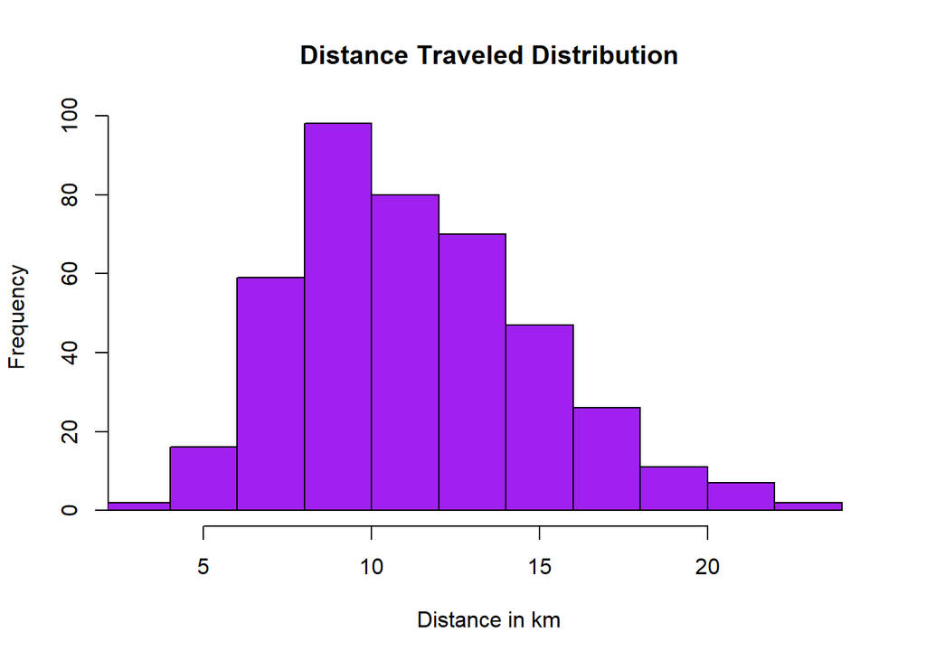

```r
hist(Distance,col="Purple",xlim=c(3,24),
     main="Distance Traveled Distribution",xlab="Distance in km",breaks=10)
```

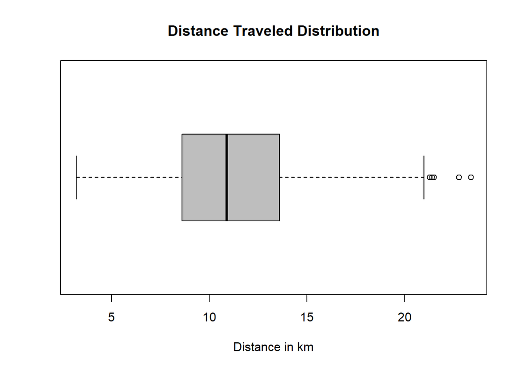

```r
boxplot(Distance,horizontal = TRUE,col="Grey",main = "Distance Traveled Distribution", xlab= "Distance in km")
```

Let us begin the outlier analysis on the “Distance” attribute. The maximum number of outliers are observed in the right side of the spectrum which is 6 in number while none in the negative spectrum of the distribution.

The observed outlier values are listed below: 21.3 21.4 21.5 21.5 22.8 23.4

```r
# OUTLIER CALCULATION
mean(Distance)
```

```
## [1] 11.29187
```

```r
median(Distance)
```

```
## [1] 10.9
```

```r
Distance_IQR = IQR(Distance)
Distance_IQR
```

```
## [1] 4.975
```

```r
#OUTLIERS - Q3
Q3_Distance = quantile(Distance,0.75)
Q3_Distance = unname(Q3_Distance)
Q3_Distance
```

```
## [1] 13.575
```

```r
#OUTLIERs - Q1
Q1_Distance = unname(quantile(Distance,0.25))
Q1_Distance
```

```
## [1] 8.6
```

```r
# IQR CALCULATION
Max_Distance_IQR = Q3_Distance+1.5*Distance_IQR # Positive Outlier Calculation
Max_Distance_IQR
```

```
## [1] 21.0375
```

```r
Min_Distance_IQR = Q1_Distance-1.5*Distance_IQR # Negative Outlier Calculation
Min_Distance_IQR
```

```
## [1] 1.1375
```

```r
# No Of OUTLIERS
sum(Distance > Max_Distance_IQR)
```

```
## [1] 6
```

```r
sum(Distance < Min_Distance_IQR)
```

```
## [1] 0
```

```r
# Print all Outliers
Distance[Distance > Max_Distance_IQR]
```

```
## [1] 21.3 21.4 21.5 21.5 22.8 23.4
```

```r
Distance[Distance < Min_Distance_IQR]
```

```
## numeric(0)
```

GENDER: Our dataset is been influenced by majority of Male employees which about 71% of the total dataset.

```r
Gender_Table=table(Gender)
Gender_Table
```

```
## Gender
## Female   Male
##    121    297
```

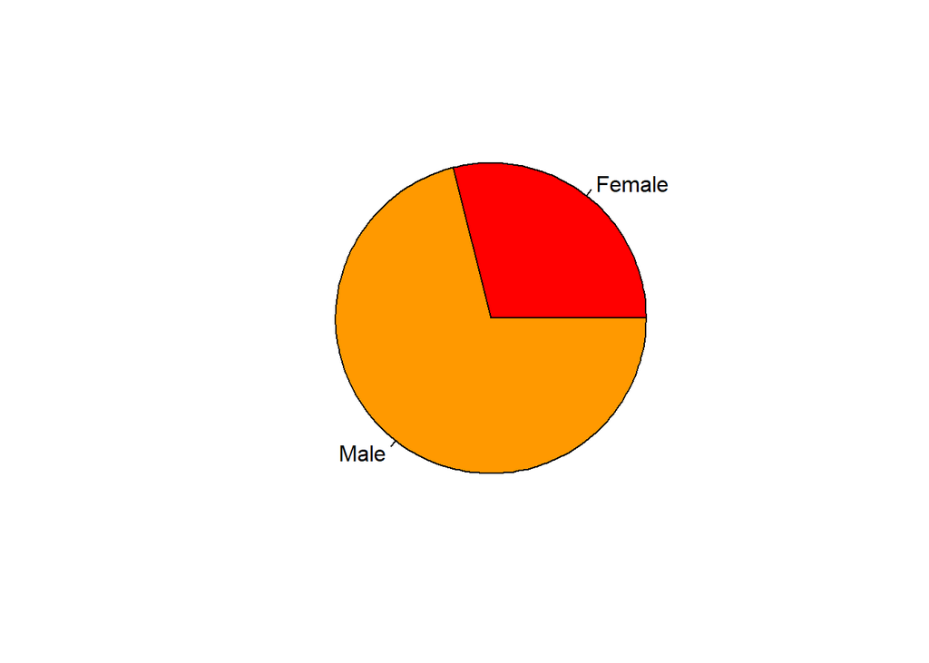

```r
pie(Gender_Table,col=rainbow(10))
```

EDUCATION: Total number of technically savy people in the dataset is 313. That is around 75% of the total dataset.

```r
Engineer_Table=table(Engineer)
Engineer_Table
```

```
## Engineer
##   0   1
## 105 313
```

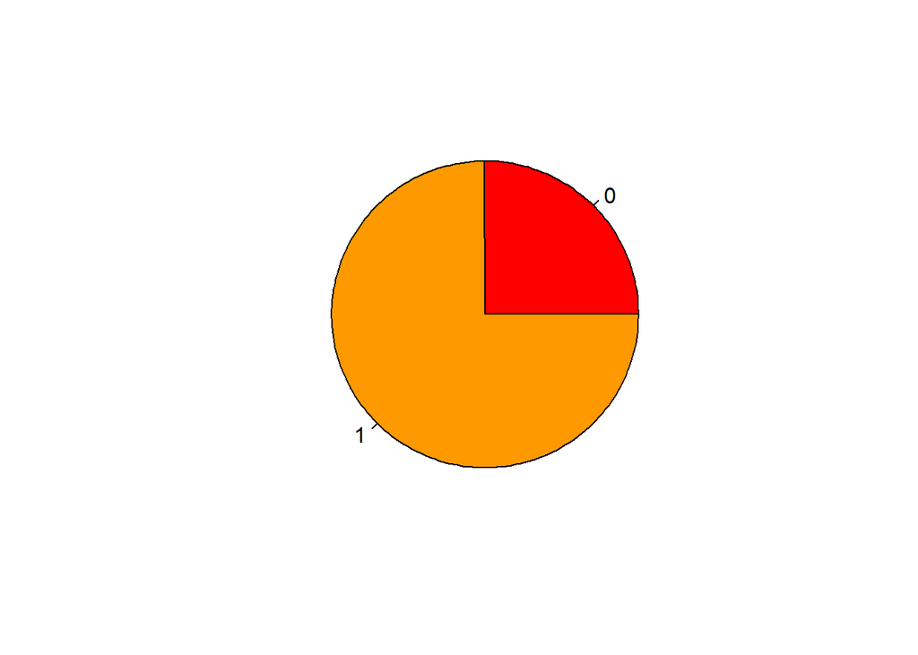

```r
pie(Engineer_Table,col=rainbow(10))
```

```r
MBA_Table=table(MBA)
MBA_Table
```

```
## MBA
##   0   1
## 309 109
```

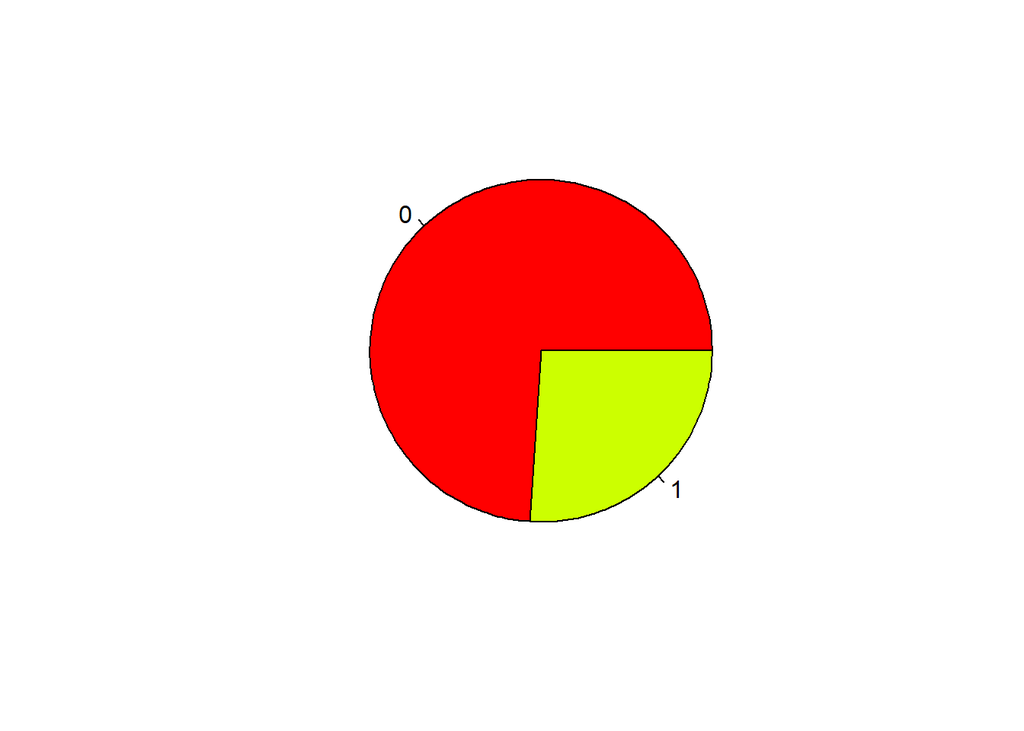

```r
pie(MBA_Table,col=rainbow(5))
```

Number of employees from the Management division with a MBA qualification is 109. That is approximately an one quarter of the observations of the dataset.

LICENSE:

It was interesting to note that only 20% people carry license. Majority does not carry any driver’s license. However, this attribute will influence from people choose cars as their mode of transport.

```r
License_Table=table(license)
License_Table
```

```
## license
##   0   1
## 333  85
```

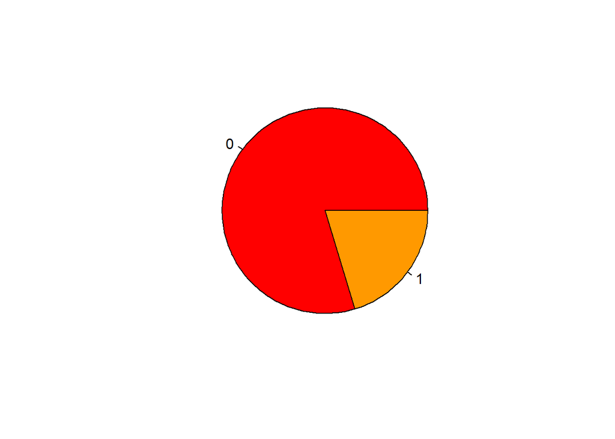

```r
pie(License_Table,col=rainbow(10))
```

TRANSPORT: Out of 418 observations 35 people own a car and 83 of them own a 2wheeler and the majority of people take the public transport.

```r
Transport_Table=table(Transport)
Transport_Table
```

```
## Transport
##         2Wheeler              Car Public Transport
##               83               35              300
```

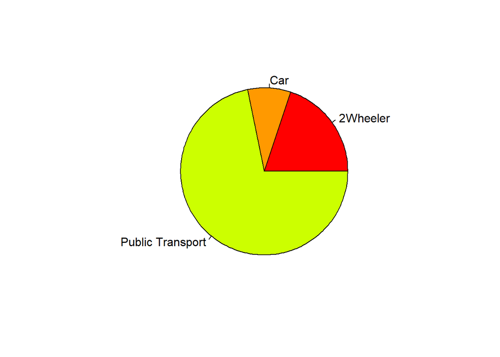

```r
pie(Transport_Table,col=rainbow(10))
```

```r
head(Cars_New_Transform,10)
```

```
##    Age Gender Engineer MBA Work.Exp Salary Distance license Transport
## 1   28   Male        1   0        5   14.4      5.1       0  2Wheeler
## 2   24   Male        1   0        6   10.6      6.1       0  2Wheeler
## 3   27 Female        1   0        9   15.5      6.1       0  2Wheeler
## 4   25   Male        0   0        1    7.6      6.3       0  2Wheeler
## 5   25 Female        0   0        3    9.6      6.7       0  2Wheeler
## 6   21   Male        0   0        3    9.5      7.1       0  2Wheeler
## 7   23   Male        1   1        3   11.7      7.2       0  2Wheeler
## 8   23   Male        0   0        0    6.5      7.3       0  2Wheeler
## 9   24   Male        1   0        4    8.5      7.5       0  2Wheeler
## 10  28   Male        1   0        6   13.7      7.5       1  2Wheeler
##    Transport.cars Male Female Education.Age Education.Gender Education.Engineer
## 1               0    1      0            28             Male                  1
## 2               0    1      0            24             Male                  1
## 3               0    0      1            27           Female                  1
```

[output cut: 40 more lines]

## MULTI-VARIATE ANALYSIS

[figure not shown]

| AGE Vs GENDER |
| --- |
| Let’s investigate the type of people who are involved in the dataset. |

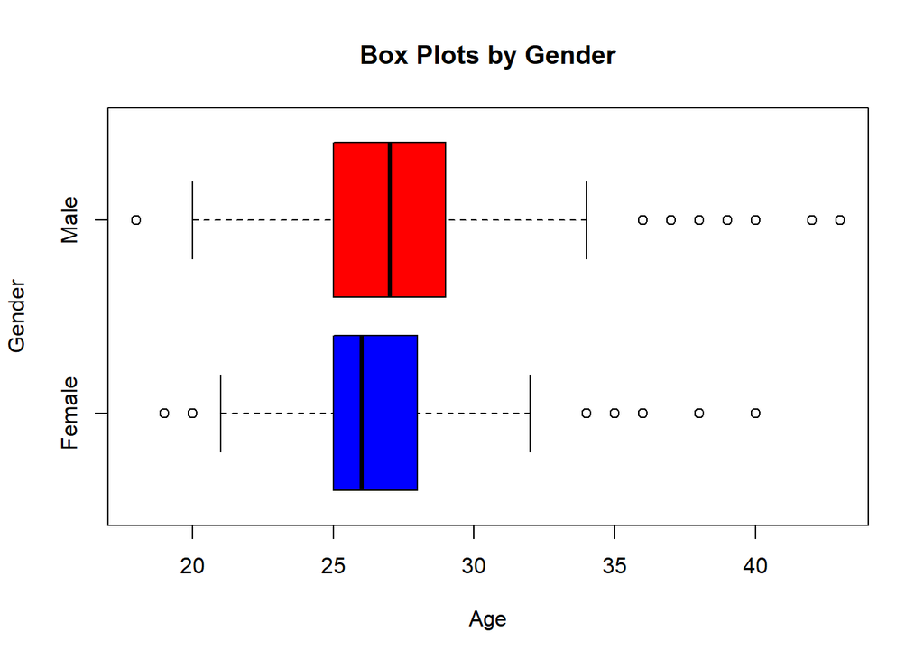

```r
boxplot(Age~Gender,data=Cars_New_Transform,horizontal=TRUE,col=c('blue','red'),main="Box Plots by Gender")
```

```r
attach(Cars_New_Transform)
table(Cars_New_Transform$Transport.cars,Cars_New_Transform$Gender)
```

```
##
##     Female Male
##   0    115  268
##   1      6   29
```

```r
#rpivotTable(Cars_New_Transform)
mean(Cars_New_Transform[Gender == "Male", "Age"],na.rm = TRUE)
```

```
## [1] 27.59259
```

```r
mean(Cars_New_Transform[Gender == "Female", "Age"],na.rm = TRUE)
```

```
## [1] 26.70248
```

```r
?mean
```

```
## starting httpd help server ...
```

```
##  done
```

```r
#View(Cars_New_Transform)
```

```r
Class.df<-Cars_New_Transform
attach(Class.df)
Distance_Class = mutate(Class.df,Distance_Class  =
ifelse(Class.df$Distance > 1 & Class.df$Distance <6,"CLOSE DISTANCE",ifelse(Class.df$Distance>5 & Class.df$Distance <10,"MEDIUM DISTANCE",
ifelse(Class.df$Distance>10 & Class.df$Distance<15,
"FAR DISTANCE","VERY FAR DISTANCE" ))))
#Distance_Class
cbind(Class.df,Distance_Class)
```

```
##     Age Gender Engineer MBA Work.Exp Salary Distance license        Transport
## 1    28   Male        1   0        5   14.4      5.1       0         2Wheeler
## 2    24   Male        1   0        6   10.6      6.1       0         2Wheeler
## 3    27 Female        1   0        9   15.5      6.1       0         2Wheeler
## 4    25   Male        0   0        1    7.6      6.3       0         2Wheeler
## 5    25 Female        0   0        3    9.6      6.7       0         2Wheeler
## 6    21   Male        0   0        3    9.5      7.1       0         2Wheeler
## 7    23   Male        1   1        3   11.7      7.2       0         2Wheeler
## 8    23   Male        0   0        0    6.5      7.3       0         2Wheeler
## 9    24   Male        1   0        4    8.5      7.5       0         2Wheeler
## 10   28   Male        1   0        6   13.7      7.5       1         2Wheeler
## 11   26   Male        0   0        4   12.6      7.5       0         2Wheeler
## 12   21   Male        0   1        3   10.6      7.7       0         2Wheeler
## 13   22 Female        1   0        2    8.5      8.1       0         2Wheeler
## 14   24   Male        1   0        6   12.7      8.7       0         2Wheeler
```

[output cut: 4175 more lines]

```r
View(Class.df)

range(Distance)
```

```
## [1]  3.2 23.4
```